# DSDA 1995

Data Science and Society using R

Lecture 5 | Data Visualization

## Plan for Today

- Why visualizing data is important
- Strategies for effective visualizations
- In class activity

## Importance of Visualizing Data

- Exploration vs. explanation
- Get a glimpse at patterns and relationships within the data
- When done well, creates value for stakeholders
- When done poorly, spreads misinformation and leads to false conclusions and flawed knowledge

## Ineffective Visualizations

- Use of 3-D to model 1-D or 2-D relationships
- Meaningless use of color
- Lack of informative labeling/titles
- Overly fancy charts
- Cluttered visualizations
- Pie charts (just…don’t)

[figure not shown]

[figure not shown]

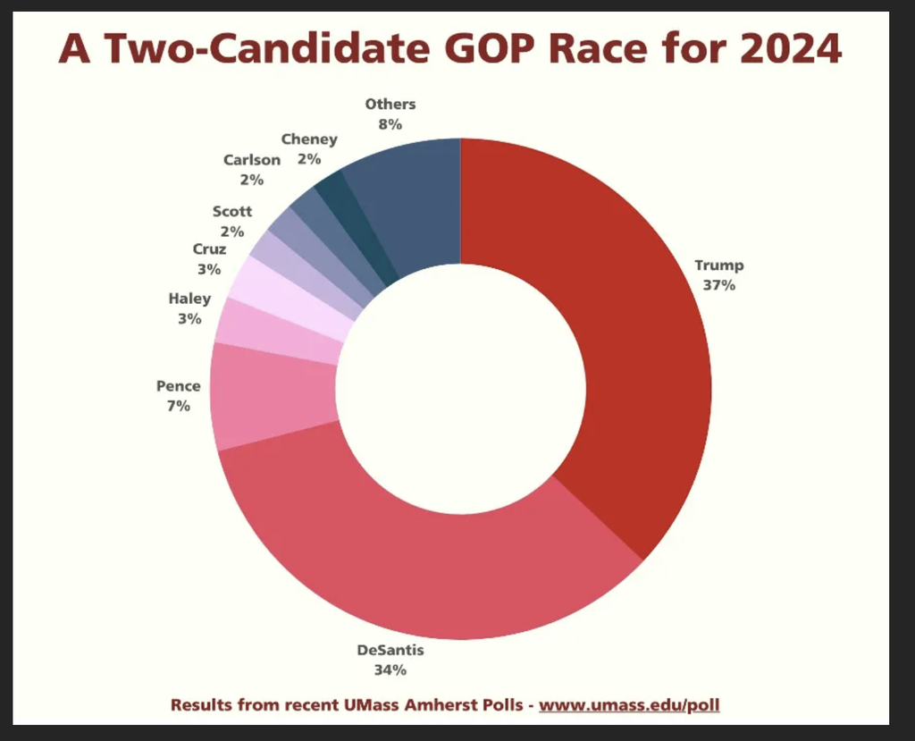